# Introduction

Central Bank, Interest Rates, and the Economy

Published

December 3, 2023

Modified

September 15, 2026

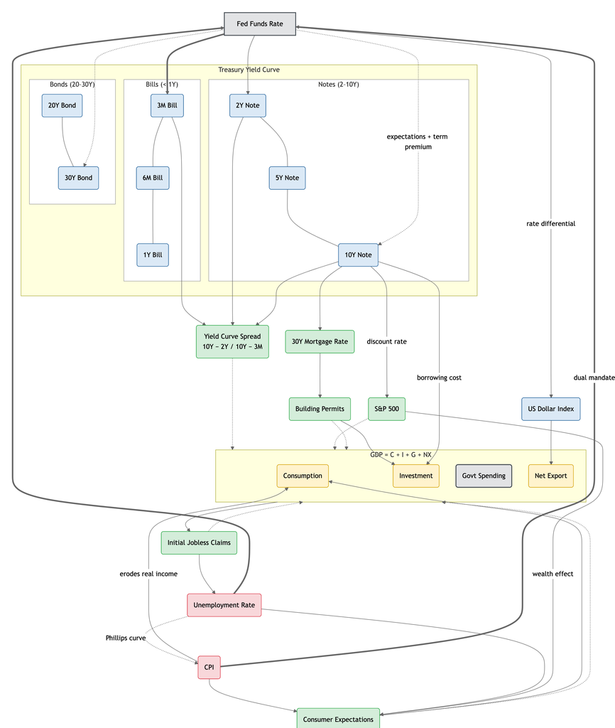

Fed Funds Rate transmission map

- **Grey** — policy instrument (Fed Funds Rate, government spending)
- **Blue** — market rates and transmission channels
- **Green** — leading indicators (turn 3–12 months before the economy)
- **Yellow** — coincident indicators (move with the economy)
- **Red** — lagging indicators (turn after the economy)
- **Thick arrows** — strongest channels
- **Dotted arrows** — leading indicators feeding into GDP

### Statement of Purpose

This project examines how changes in the Federal Funds Rate pass through to other parts of the U.S. economy. The series covered are Treasury yields and spreads across the curve, real GDP, CPI inflation, the unemployment rate, the 30-year mortgage rate, the U.S. dollar index, the S&P 500, and consumer sentiment. This page describes the channels involved; the map above includes nodes such as jobless claims and building permits that place the modelled series in context but are not themselves modelled. Later sections test the channels with time series models: univariate ARMA models, regressions and vector autoregressions with the Federal Funds Rate, a GARCH model of dollar volatility, and recurrent neural networks.

The starting point is the Harvard Law Review (2023) note on the Federal Reserve’s rate increase of March 22, 2023, *Federal Reserve — U.S. Monetary Policy Shows the Major Issues with the Major Questions Doctrine*

[video not shown]

### Central Bank

A central bank is the institution responsible for a country’s monetary policy. In the United States this is the Federal Reserve System. Other examples are the Bank of England and the European Central Bank. The main tools are the policy interest rate, the size of the balance sheet, and guidance about future policy. Because the dollar is the main funding and reserve currency, Federal Reserve decisions also affect borrowing costs and exchange rates outside the United States.

### Interest Rate

The policy rate is the central bank’s primary tool. A higher rate raises the cost of borrowing for households and firms. Consumption and investment slow, and GDP growth slows with them. Inflation responds later, usually with a lag of a year or more. A lower rate works in the opposite direction.

### Fed Funds Rate

The Federal Funds Rate is the overnight rate at which banks lend reserves to each other. The Federal Open Market Committee sets a target range for it at eight scheduled meetings a year. It is the shortest rate in the economy and the anchor for the rest of the yield curve. Bills maturing within a year track it closely. Longer maturities respond less directly, since their yields also reflect expected future policy, expected inflation, and a term premium. Longer-term yields in turn set borrowing costs for mortgages and corporate debt and the discount rate applied to equities.

[interactive chart not shown]

### Gross Domestic Product

GDP is the sum of consumption, investment, government spending, and net exports. Consumption is roughly two-thirds of the total. Rate changes reach GDP mainly through investment (housing and business capital spending) and consumption (credit costs and the wealth effect from asset prices). Net exports respond through the exchange rate: higher U.S. rates relative to other countries strengthen the dollar, which makes imports cheaper and exports more expensive.

GDP is a coincident indicator. It is published quarterly, about a month after the quarter ends, and is revised for several years afterward.

### Risk-Free Rate

The risk-free rate is the return on an asset with no default risk. In practice U.S. Treasury yields are used, with the maturity matched to the horizon in question: the 3-month bill for short horizons and the 10-year note for longer ones. The rate is nominal and therefore includes expected inflation. The real risk-free rate is observed from Treasury Inflation-Protected Securities (TIPS). LIBOR served as the short-term benchmark for decades but was discontinued in June 2023 and replaced by SOFR, which is based on overnight Treasury repo transactions.

### U.S. Treasury Securities

The Treasury issues three types of marketable debt. Bills mature in 4 to 52 weeks, are sold at a discount, and pay no coupon. Notes mature in 2, 3, 5, 7, or 10 years. Bonds mature in 20 or 30 years. Notes and bonds pay interest semi-annually. All three are backed by the full faith and credit of the U.S. government and are treated as free of default risk. The Treasury market is the largest and most liquid bond market in the world, and its yields serve as reference rates for most other dollar borrowing. The 10-year note is the most widely quoted. The 30-year mortgage rate, for example, is priced as a spread over the 10-year yield rather than over the 30-year bond, because most mortgages are repaid or refinanced well before maturity.

### Treasury Yield Curve

The yield curve plots Treasury yields against maturity on a given day. It normally slopes upward, since investors require more yield to lend for longer. The slope is usually summarized as a spread, most often the 10-year yield minus the 2-year yield or the 10-year minus the 3-month. An inverted curve, where short yields exceed long yields, has preceded every U.S. recession since the late 1960s, typically by 6 to 18 months. This makes the spread one of the most closely watched leading indicators. The Federal Funds Rate sets the short end of the curve directly. The long end is set by the market.

[interactive chart not shown]

U.S. Department of Treasury (2026)

### Summary

The Federal Reserve sets the Federal Funds Rate. Short-maturity Treasury yields follow it closely, and long-maturity yields follow it partially, adjusted for expectations and term premium. Those yields set borrowing costs across the economy, and borrowing costs move investment, consumption, asset prices, and the exchange rate. Employment and inflation respond last. Since the Fed’s mandate variables are lagging indicators, the Fed relies on leading indicators such as the yield curve spread, equity prices, and jobless claims to judge where the economy is heading. The remaining sections of this project test these relationships in the data.

## References

Harvard Law Review. 2023. *Federal Reserve Interest Rate Hike on March 22, 2023*. 136 (7): 2028–35. https://harvardlawreview.org/print/vol-136/federal-reserve-interest-rate-hike-on-march-22-2023/.

U.S. Department of Treasury. 2026. *Daily Treasury Rates*. [Https://home.treasury.gov/resource-center/data-chart-center/interest-rates/TextView?type=daily_treasury_yield_curve](https://home.treasury.gov/resource-center/data-chart-center/interest-rates/TextView?type=daily_treasury_yield_curve).